# Dataverse from Nodejs

Muhammed Ewis

# Dataverse from Nodejs

How to query and alert Microsoft dataverse from NodeJS.

# Create a new Azure Active Directory app

We need an app to write/read the tables for us. Create a new one from [here](https://aad.portal.azure.com/#view/Microsoft_AAD_IAM/ActiveDirectoryMenuBlade/~/RegisteredApps).

[figure not shown]

After giving it a name, we need to grant it access for the CRM, locate the CRM permission

[figure not shown]

Enable it and select enabling `user_impersonation`.

To be able to run the code locally (read/write) from your computer, we need to have your computer at the MSAL authentication list.

To do this, in the sidebar of the app, select Authentication > + Add a platform > Mobile and desktop applications > Add the url http://localhost

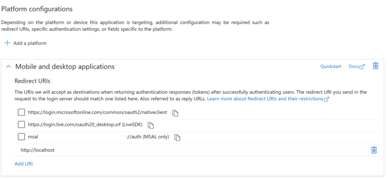

Scroll down to Advanced settings and select Yes to Allow public client flows.

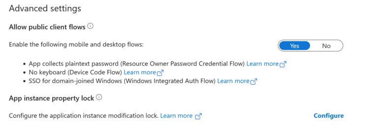

Finally we need to get the app information, In the sidebar, click on Overview in the app sidebar and note the following details:

- client id
- client secret

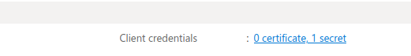

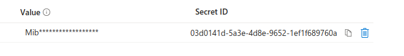

In case if there is none, create a one. Also in case of that you lost your id value, delete it and create a new one (that you can store its value).

Let's see all the keys we have so far:

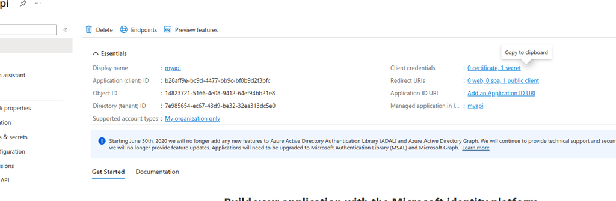

From this overview, we can get the Application (client) ID and Directory (tenant) ID. And from the power platform admin center we an find the environment url:

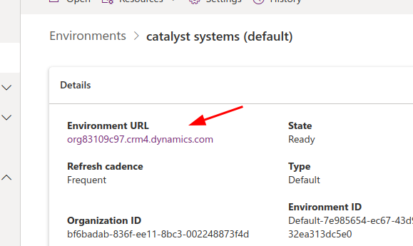

- Directory (tenant) ID
- Application (client) ID
- Client Secret
- Environment URL

# Add the created app to your environment

Go to Power Platform admin center https://admin.powerplatform.microsoft.com/ And jump to "environments".

[figure not shown]

From there, click settings over the environment you are going to use

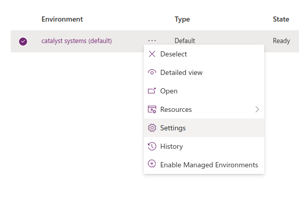

Go to Users + premssions and choose application users

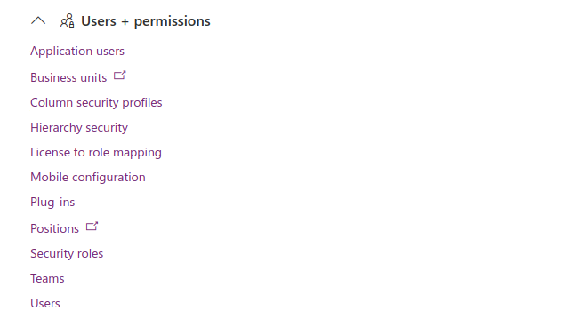

Finally choose the app and give it your suitable security roles

# Read and write tables from node code

I will make a new table for the sake of this tutorial. Let's go to power apps https://make.powerapps.com/ select your environment and jump to tables

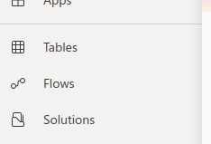

I've created a table already called newtab. Note that we deal with the real name of the table in the code, not the given name. the real name is presented at the second column:

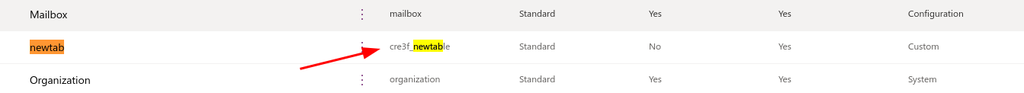

You can copy it from here after opening the table:

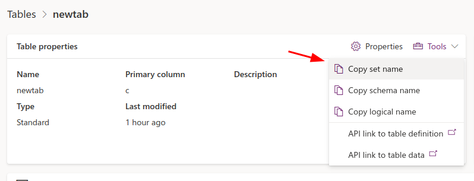

My table contains only one column named "c".

So my table real name is `cre3f_newtables` we also need to get the column real name. We can do so by clicking edit column

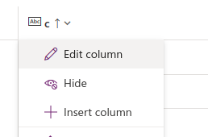

And from the advanced option we can see the schema name:

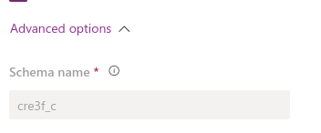

# Code

Let's write some code now, replace the values you collected in the following block

```javascript
import { DynamicsWebApi } from "dynamics-web-api";
import * as dwa from 'dynamics-web-api';
import * as MSAL from '@azure/msal-node';

// put the Directory (tenant) ID after the slash here
const authorityUrl = 'https://login.microsoftonline.com/7e985654-ec67-43d9-be32-32ea313dc5e0';

const msalConfig = {
    auth: {
        authority: authorityUrl,
        // your Application (client) ID
        clientId: 'b28aff9e-bc9d-4477-bb9c-bf0b9d2f3bfc',
        // Client Secret
        clientSecret: 'Mib8Q~ZP1qoc_1HPgxdMAnaTdZ3uxkSseWktYa~f',
        knownAuthorities: ['login.microsoftonline.com']
    }
}

const cca = new MSAL.ConfidentialClientApplication(msalConfig);

// your Environment URL
const serverUrl = 'https://org83109c97.crm4.dynamics.com';

//function that acquires a token and passes it to DynamicsWebApi
const acquireToken = async () => {
    try {
        return cca.acquireTokenByClientCredential({
            scopes: [`${serverUrl}/.default`],
        });
    }
    catch (error) {
        return null;
    }
}

const dynamicsWebApi = new DynamicsWebApi({
    serverUrl: serverUrl,
    onTokenRefresh: acquireToken
});
```

Now finally let's model the table to insert:

```javascript
async function main(): Promise<void> {
    interface newtab {
        cre3f_c?: string,
        cid?: string
    }

    //init an object representing Dynamics 365 entity
    const lead: newtab = {
        cre3f_c: "w11"
    };

    //init DynamicsWebApi request
    const request: dwa.CreateRequest = {
        collection: "cre3f_newtables",
        data: lead,
        returnRepresentation: true
    }
    const result = await dynamicsWebApi.create<newtab>(request);

}


try {
    main()
}
catch (error) {
    console.log(error);
}
```

Note:

`cre3f_c` is the c property real name, and the cid is a required value for the primary key (but we do not fill it), if i had a table named "names" i'd have it instead namesid, and so on.

For retrieving, deleting and updating the data, it is just as simple, we will just use instead the corresponding functions, for example, if we to retriev some row we would use `const result = await dynamicsWebApi.retrieve<newtab>(request);` instead. The package provide clear examples for doing so https://github.com/AleksandrRogov/DynamicsWebApi?tab=readme-ov-file#retrieve-a-table-row

Reading all the data from the table:

```javascript
const response = await dynamicsWebApi.retrieveMultiple<newtab>(listrequest);

const count = response.oDataCount;
const nextLink = response.oDataNextLink;
const records = response.value;

for (let i = 0; i < count; i++) {
    console.log("C value: " + records[i].cre3f_c);
}
```